# STAT318Assignment3

## **Question 1**

### There are 150 rows and 5 columns/variables. The variables are Sepal.length, Sepal.Width, Petal.Length, Petal.Width and Species.

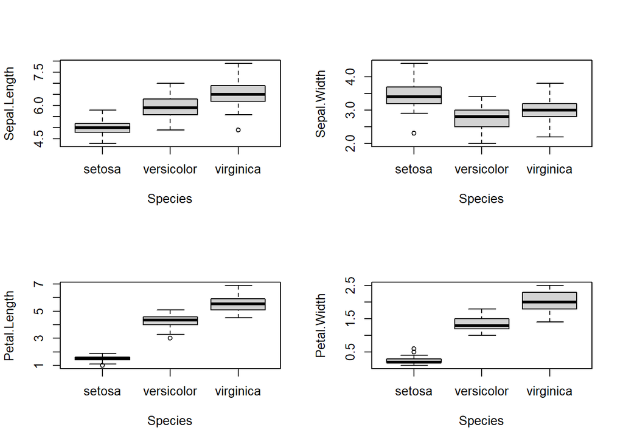

```r
# b)
# Group by species
par(mfrow=c(2,2))
boxplot(Sepal.Length~Species, data = iris)
boxplot(Sepal.Width~Species, data = iris)
boxplot(Petal.Length~Species, data = iris)
boxplot(Petal.Width~Species, data = iris)
```

```r
# c)
summary(iris)
```

```
##   Sepal.Length    Sepal.Width     Petal.Length    Petal.Width
##  Min.   :4.300   Min.   :2.000   Min.   :1.000   Min.   :0.100
##  1st Qu.:5.100   1st Qu.:2.800   1st Qu.:1.600   1st Qu.:0.300
##  Median :5.800   Median :3.000   Median :4.350   Median :1.300
##  Mean   :5.843   Mean   :3.057   Mean   :3.758   Mean   :1.199
##  3rd Qu.:6.400   3rd Qu.:3.300   3rd Qu.:5.100   3rd Qu.:1.800
##  Max.   :7.900   Max.   :4.400   Max.   :6.900   Max.   :2.500
##        Species
##  setosa    :50
##  versicolor:50
##  virginica :50
##
##
##
```

## The data is not unbalacned as there are 3 classes in species (setosa, versicolor, virginica) with all equal ratios 50:50:50.

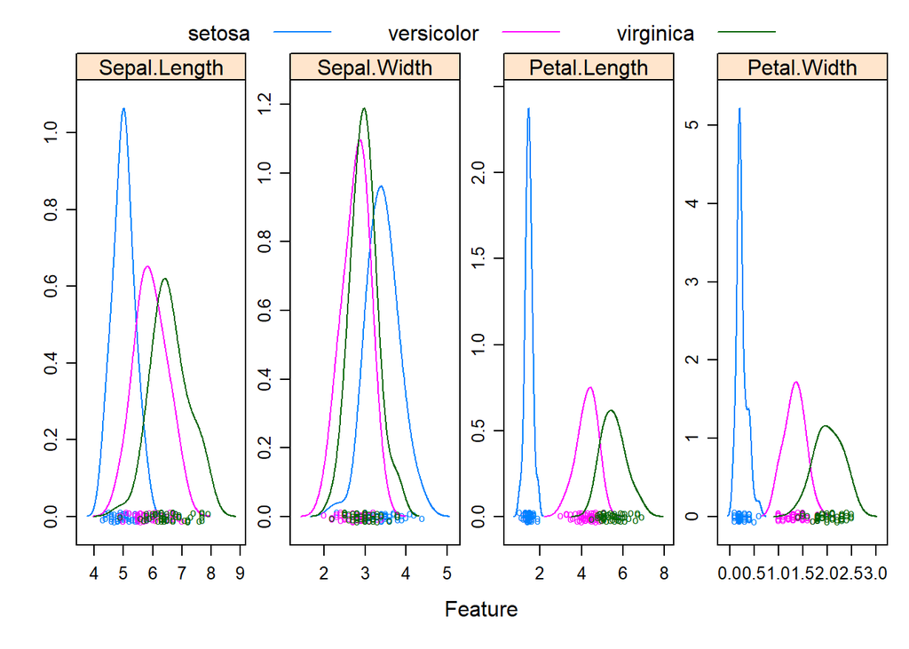

```r
#d)

x <- iris[, 1:4]
y <- iris$Species
caret::featurePlot(x,
                   y,
                   plot="density",
                   scales = list(x = list(relation="free"),
                                 y = list(relation="free")),
                   adjust = 1.5,
                   pch = "o",
                   layout = c(4, 1),
                   auto.key = list(columns = 3))
```

### From the density plot for petal length and petal width, we can see that the density of setosa flower does not overlap with the densities of the versicolor and virginica iris flowers.Because there is no overlap these might be better predictors for flower species.

### In the Sepal.Length and Sepal.Width plot all three densities (setosa, versicolor and virginica) have overlap which may mean they are not as significant for predictions. There is a a lot more overlap between all three species for the sepal length and sepal width features, so these variables are not as significant in predictions.

```r
#e)
nfolds <- 10
traincontrol = trainControl(method = "cv",
                            number = nfolds)
LDA <- train(Species ~ .,
             data = iris,
             method = "lda",
             trControl = traincontrol)

KNN <- train(Species ~ .,
             data = iris,
             method = "knn",
             tuneGrid   = expand.grid(k = c(1,2,3,4,5,6,7,8,9,10)),
             trControl = traincontrol,
             metric="Accuracy")

results <- resamples(list(lda=LDA, knn=KNN))
summary(results)
```

```
##
## Call:
## summary.resamples(object = results)
##
## Models: lda, knn
## Number of resamples: 10
##
## Accuracy
##          Min. 1st Qu. Median Mean 3rd Qu. Max. NA's
## lda 0.9333333    0.95      1 0.98       1    1    0
## knn 0.9333333    0.95      1 0.98       1    1    0
##
## Kappa
##     Min. 1st Qu. Median Mean 3rd Qu. Max. NA's
## lda  0.9   0.925      1 0.97       1    1    0
## knn  0.9   0.925      1 0.97       1    1    0
```

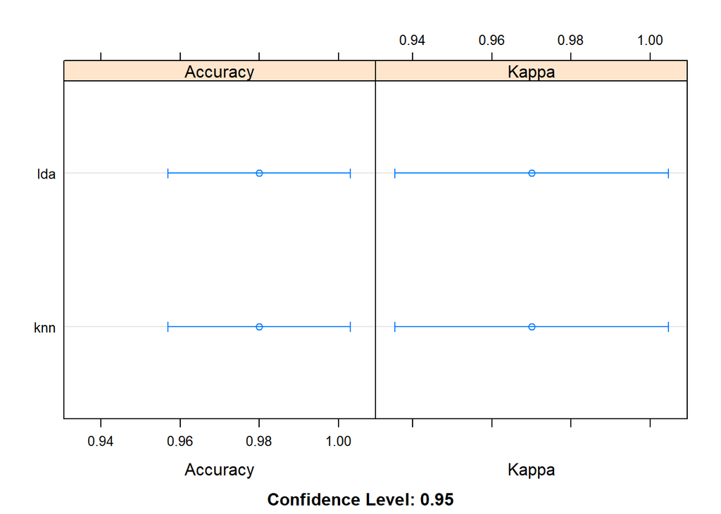

```r
dotplot(results)
```

## Question 2

```r
#a
library(ISLR2)
summary(Credit)
```

```
##      Income           Limit           Rating          Cards
##  Min.   : 10.35   Min.   :  855   Min.   : 93.0   Min.   :1.000
##  1st Qu.: 21.01   1st Qu.: 3088   1st Qu.:247.2   1st Qu.:2.000
##  Median : 33.12   Median : 4622   Median :344.0   Median :3.000
##  Mean   : 45.22   Mean   : 4736   Mean   :354.9   Mean   :2.958
##  3rd Qu.: 57.47   3rd Qu.: 5873   3rd Qu.:437.2   3rd Qu.:4.000
##  Max.   :186.63   Max.   :13913   Max.   :982.0   Max.   :9.000
##       Age          Education      Own      Student   Married     Region
##  Min.   :23.00   Min.   : 5.00   No :193   No :360   No :155   East : 99
##  1st Qu.:41.75   1st Qu.:11.00   Yes:207   Yes: 40   Yes:245   South:199
##  Median :56.00   Median :14.00                                 West :102
##  Mean   :55.67   Mean   :13.45
##  3rd Qu.:70.00   3rd Qu.:16.00
##  Max.   :98.00   Max.   :20.00
##     Balance
##  Min.   :   0.00
##  1st Qu.:  68.75
##  Median : 459.50
##  Mean   : 520.01
##  3rd Qu.: 863.00
##  Max.   :1999.00
```

```r
dim(Credit)
```

```
## [1] 400  11
```

### There are 400 rows and 11 columns/variables. The variables are Income, Limit, Rating, Cards, Age, Education, Own, Student, Married, Region, Balance.

```r
#b
creditBalanceMean <- mean(Credit$Balance)
creditBalanceMean
```

```
## [1] 520.015
```

### estimate for the population mean of the credit card balance is $520.015.

```r
#c
n_observation <- nrow(Credit)
SE <- sd(Credit$Balance) / sqrt(n_observation)
SE
```

```
## [1] 22.98794
```

### Estimate of the standard error is $22.98794.

```r
#d
library(boot)
meanfunc = function(x, index) {
  return(mean(x$Balance[index]))
}

bootSE = boot(Credit, meanfunc, R=1000)
bootSE
```

```
##
## ORDINARY NONPARAMETRIC BOOTSTRAP
##
##
## Call:
## boot(data = Credit, statistic = meanfunc, R = 1000)
##
##
## Bootstrap Statistics :
##     original   bias    std. error
## t1*  520.015 1.016368    22.33885
```

```r
bootSEval <- 22.23329
```

```r
lower <- creditBalanceMean - 2*bootSEval
upper <- creditBalanceMean + 2*bootSEval
CI <- c(lower, upper)
CI
```

```
## [1] 475.5484 564.4816
```

```r
t.test(Credit$Balance, conf.level = 0.95)
```

```
##
##  One Sample t-test
##
## data:  Credit$Balance
## t = 22.621, df = 399, p-value < 2.2e-16
## alternative hypothesis: true mean is not equal to 0
## 95 percent confidence interval:
##  474.8224 565.2076
## sample estimates:
## mean of x
##   520.015
```

### From the results we can see that they are very similar/values are very close to each other.

# Question 3

```r
setwd("H:/Documents/STAT318/Assignments/Assignment3")
training = read.csv("carseatsTrain.csv")
testing = read.csv("carseatsTest.csv")

training
```

| Sales | CompPrice | Income | Advertising | Population | ShelveLoc | Age | Education | Urban | US |
| --- | --- | --- | --- | --- | --- | --- | --- | --- | --- |
| 5.04 | 123 | 114 | 0 | 298 | Bad | 34 | 16 | Yes | No |
| 6.85 | 143 | 81 | 5 | 60 | Medium | 61 | 18 | Yes | Yes |
| 5.68 | 113 | 22 | 1 | 317 | Medium | 28 | 12 | Yes | No |
| 11.48 | 121 | 120 | 13 | 140 | Medium | 56 | 11 | Yes | Yes |
| 10.71 | 109 | 22 | 10 | 348 | Good | 74 | 14 | No | Yes |
| 0.16 | 102 | 33 | 0 | 217 | Medium | 70 | 18 | No | No |
| 3.02 | 98 | 21 | 11 | 326 | Bad | 76 | 11 | No | Yes |
| 5.30 | 113 | 22 | 0 | 57 | Medium | 65 | 16 | No | No |
| 11.07 | 131 | 84 | 11 | 29 | Medium | 44 | 17 | No | Yes |
| 5.07 | 123 | 91 | 0 | 334 | Bad | 78 | 17 | Yes | Yes |

[output cut: 256 more lines]

```r
testing
```

| Sales | CompPrice | Income | Advertising | Population | ShelveLoc | Age | Education | Urban | US |
| --- | --- | --- | --- | --- | --- | --- | --- | --- | --- |
| 9.50 | 138 | 73 | 11 | 276 | Bad | 42 | 17 | Yes | Yes |
| 4.15 | 141 | 64 | 3 | 340 | Bad | 38 | 13 | Yes | No |
| 11.17 | 107 | 117 | 11 | 148 | Good | 52 | 18 | Yes | Yes |
| 12.29 | 147 | 74 | 13 | 251 | Good | 52 | 10 | Yes | Yes |
| 13.91 | 110 | 110 | 0 | 408 | Good | 46 | 17 | No | Yes |
| 12.13 | 134 | 29 | 12 | 239 | Good | 62 | 18 | No | Yes |
| 5.08 | 128 | 46 | 6 | 497 | Medium | 42 | 13 | Yes | No |
| 10.14 | 145 | 119 | 16 | 294 | Bad | 42 | 12 | Yes | Yes |
| 14.90 | 139 | 32 | 0 | 176 | Good | 54 | 11 | No | No |
| 5.27 | 98 | 118 | 0 | 19 | Medium | 64 | 17 | Yes | No |

[output cut: 124 more lines]